# DS202 Final Project Team2

Feifan Cao, Haoran Wang, Wenzheng Wang, Chuxiao Yu

11/1/2022

## Data set

We get our data set from the link “https://www.kaggle.com/datasets/whenamancodes/students-performance-in-exams”. We also created a github for this project, the downloaded data set and R markdown file can be find under this github link “https://github.com/chuxiaoy/DS202_final_project”. First of all, we are going to read our data:

```r
data <- read.csv("exams.csv")
```

```r
variable.names(data)
```

```
## [1] "gender"                      "race.ethnicity"
## [3] "parental.level.of.education" "lunch"
## [5] "test.preparation.course"     "math.score"
## [7] "reading.score"               "writing.score"
```

This data set consists of the marks secured by the students in various subjects. It includes gender, race, their parent level of education, lunch, test preparation course， math score, reading score and writing score. We would like to anlayze what effects students the most about their scores.

```r
dim(data)
```

```
## [1] 1000    8
```

```r
str(data)
```

```
## 'data.frame':    1000 obs. of  8 variables:
##  $ gender                     : chr  "male" "female" "male" "male" ...
##  $ race.ethnicity             : chr  "group A" "group D" "group E" "group B" ...
##  $ parental.level.of.education: chr  "high school" "some high school" "some college" "high school" ...
##  $ lunch                      : chr  "standard" "free/reduced" "free/reduced" "standard" ...
##  $ test.preparation.course    : chr  "completed" "none" "none" "none" ...
##  $ math.score                 : int  67 40 59 77 78 63 62 93 63 47 ...
##  $ reading.score              : int  67 59 60 78 73 77 59 88 56 42 ...
##  $ writing.score              : int  63 55 50 68 68 76 63 84 65 45 ...
```

There is a total of 1000 rows with 8 variables in our data set. There are 5 character variables which are gender, race.ethnicity, parental.level.of.education, lunch, and test.preparation.courcee. There are 3 numerical variables that are math.score, reading.score, writing.score.

```r
summary(data$math.score)
```

```
##    Min. 1st Qu.  Median    Mean 3rd Qu.    Max.
##    13.0    56.0    66.5    66.4    77.0   100.0
```

```r
summary(data$reading.score)
```

```
##    Min. 1st Qu.  Median    Mean 3rd Qu.    Max.
##      27      60      70      69      79     100
```

```r
summary(data$writing.score)
```

```
##    Min. 1st Qu.  Median    Mean 3rd Qu.    Max.
##   23.00   58.00   68.00   67.74   79.00  100.00
```

According to the previous code, we get the summary for all the three numerical values. We can see that the minimum math score is 13, the median of reading score is 70 and the maximim of writing score is 100.

```r
library(tidyverse)
```

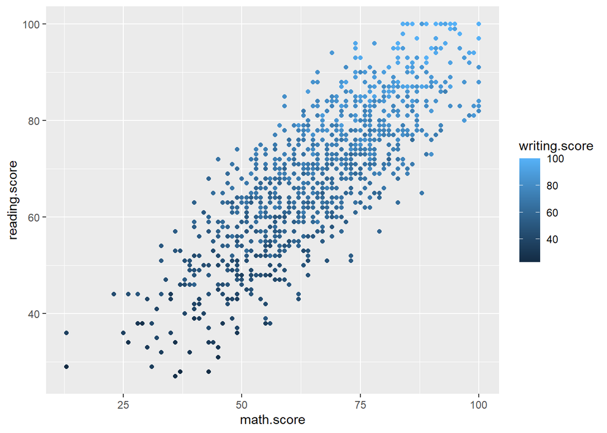

```r
ggplot(data=data,aes(x=math.score, y=reading.score, color=writing.score))+geom_point()
```

In this scatter plot, we can see that there is relationship between math score, reading score and writing score. As math score increase, reading score increase. As math score rises, writing score also increase.

```r
levels(factor(data$gender))
```

```
## [1] "female" "male"
```

```r
levels(factor(data$race.ethnicity))
```

```
## [1] "group A" "group B" "group C" "group D" "group E"
```

```r
levels(factor(data$parental.level.of.education))
```

```
## [1] "associate's degree" "bachelor's degree"  "high school"
## [4] "master's degree"    "some college"       "some high school"
```

```r
levels(factor(data$lunch))
```

```
## [1] "free/reduced" "standard"
```

```r
levels(factor(data$test.preparation.course))
```

```
## [1] "completed" "none"
```

In this code that we analysized all the character variables. We can see that Two levels in gender: “female” “male” Five levels in race: “group A” “group B” “group C” “group D” “group E” Six levels in education: “associate’s degree”, “bachelor’s degree”, “high school”, “master’s degree”, “some college”, “some high school” Two levels in lunch: “free/reduced” “standard” Two levels in preparation course: “completed” “none”